# Analisis_de_Datos_Omicos

Raúl Pérez Prats

2024-03-31

## R Markdown

### GEO Series

```r
library(GEOquery)
gse <- getGEO("GSE5370",GSEMatrix=FALSE)
```

```
## Reading file....
```

```
## Parsing....
```

[output not shown]

[output not shown]

[output not shown]

[output not shown]

[output not shown]

[output not shown]

[output not shown]

[output not shown]

[output not shown]

[output not shown]

[output not shown]

```r
head(Meta(gse))
```

```
## $contact_address
## [1] "PO Box 6000"
##
## $contact_city
## [1] "Binghamton"
##
## $contact_country
## [1] "USA"
##
## $contact_department
## [1] "Pharmaceutical Sciences"
##
## $contact_email
## [1] "ericphoffman@gmail.com"
##
## $contact_institute
## [1] "Binghamton University - SUNY"
```

```r
# names of all the GSM objects contained in the GSE

names(GSMList(gse))
```

```
## [1] "GSM74359"  "GSM74360"  "GSM118580" "GSM118624" "GSM118659" "GSM118660"
## [7] "GSM118661" "GSM119936" "GSM119937"
```

```r
# and get the first GSM object on the list

GSMList(gse)[[1]]
```

```
## An object of class "GSM"
## channel_count
## [1] "1"
## characteristics_ch1
## [1] "Control"
## contact_address
## [1] "PO Box 6000"
## contact_city
## [1] "Binghamton"
## contact_country
## [1] "USA"
## contact_department
## [1] "Pharmaceutical Sciences"
## contact_email
## [1] "ericphoffman@gmail.com"
## contact_institute
## [1] "Binghamton University - SUNY"
## contact_name
## [1] "Eric,P,Hoffman"
## contact_state
## [1] "NY"
## contact_zip/postal_code
## [1] "13902"
## data_processing
## [1] "Affymetrix MAS5.0"
## data_row_count
## [1] "22283"
## description
## [1] "Normal volunteer;  RNA extracted from muscle biopsy, which was flash-frozen in isopentane cooled in liquid nitrogen immediately after excision"
## geo_accession
## [1] "GSM74359"
## hyb_protocol
## [1] "standard Affymetrix procedures"
## label_ch1
## [1] "biotin"
## last_update_date
## [1] "Oct 01 2019"
## molecule_ch1
## [1] "total RNA"
## organism_ch1
```

[output cut: 20 more lines]

```
## [1] "RNA"
## An object of class "GEODataTable"
## ****** Column Descriptions ******
##     Column                                      Description
## 1                                                  ID_REF =
## 2    VALUE                                    SIGNAL MAS5.0
## 3 ABS_CALL Presence or Absence of gene transcript in sample
## ****** Data Table ******
##      ID_REF     VALUE ABS_CALL
## 1 1007_s_at 1152.7227        P
## 2   1053_at  287.9037        P
## 3    117_at  365.0911        A
## 4    121_at 5159.1284        P
## 5 1255_g_at  246.9429        A
## 22278 more rows ...
```

```r
# and the names of the GPLs represented

names(GPLList(gse))
```

```
## [1] "GPL96"
```

```r
gsmplatforms <- lapply(GSMList(gse),function(x) {Meta(x)$platform_id})
head(gsmplatforms)
```

```
## $GSM74359
## [1] "GPL96"
##
## $GSM74360
## [1] "GPL96"
##
## $GSM118580
## [1] "GPL96"
##
## $GSM118624
## [1] "GPL96"
##
## $GSM118659
## [1] "GPL96"
##
## $GSM118660
## [1] "GPL96"
```

```r
gsmlist = Filter(function(gsm) {Meta(gsm)$platform_id=='GPL96'},GSMList(gse))
length(gsmlist)
```

```
## [1] 9
```

```r
Table(gsmlist[[1]])[1:5,]
```

```
##      ID_REF     VALUE ABS_CALL
## 1 1007_s_at 1152.7227        P
## 2   1053_at  287.9037        P
## 3    117_at  365.0911        A
## 4    121_at 5159.1284        P
## 5 1255_g_at  246.9429        A
```

```r
# and get the column descriptions
Columns(gsmlist[[1]])[1:5,]
```

```
##        Column                                      Description
## 1                                                     ID_REF =
## 2       VALUE                                    SIGNAL MAS5.0
## 3    ABS_CALL Presence or Absence of gene transcript in sample
## NA       <NA>                                             <NA>
## NA.1     <NA>                                             <NA>
```

```r
# get the probeset ordering
probesets <- Table(GPLList(gse)[[1]])$ID
# make the data matrix from the VALUE columns from each GSM
# being careful to match the order of the probesets in the platform
# with those in the GSMs
data.matrix <- do.call('cbind',lapply(gsmlist,function(x)
                                      {tab <- Table(x)
                                       mymatch <- match(probesets,tab$ID_REF)
                                       return(tab$VALUE[mymatch])
                                     }))
data.matrix <- apply(data.matrix,2,function(x) {as.numeric(as.character(x))})
data.matrix <- log2(data.matrix)
data.matrix[1:5,]
```

```
##       GSM74359  GSM74360 GSM118580 GSM118624 GSM118659 GSM118660 GSM118661
## [1,] 10.170830 11.015572 10.748962 10.839499 11.114192 10.868025 10.992740
## [2,]  8.169442  7.806341  8.022196  8.122973  7.352121  8.259086  6.674912
## [3,]  8.512113  8.468444  8.477708  8.591078  8.889361  8.653234  8.425472
## [4,] 12.332912 12.718073 11.202286 11.105270 11.282541 11.153632 11.282462
## [5,]  7.948034  9.268065  6.919047  7.015394  7.443966  5.977006  7.843824
##      GSM119936 GSM119937
## [1,] 10.765148 10.779174
## [2,]  8.079535  8.614852
## [3,]  9.037756  8.946878
## [4,] 11.611107 11.796270
## [5,]  7.582632  7.590664
```

```r
require(Biobase)
# go through the necessary steps to make a compliant ExpressionSet
rownames(data.matrix) <- probesets
colnames(data.matrix) <- names(gsmlist)
pdata <- data.frame(samples=names(gsmlist))
rownames(pdata) <- names(gsmlist)
pheno <- as(pdata,"AnnotatedDataFrame")
eset2 <- new('ExpressionSet',exprs=data.matrix,phenoData=pheno)
eset2
```

```
## ExpressionSet (storageMode: lockedEnvironment)
## assayData: 22283 features, 9 samples
##   element names: exprs
## protocolData: none
## phenoData
##   sampleNames: GSM74359 GSM74360 ... GSM119937 (9 total)
##   varLabels: samples
##   varMetadata: labelDescription
## featureData: none
## experimentData: use 'experimentData(object)'
## Annotation:
```

## GEO DataSet

### 1.

Hemos escojido el dataset correspondiente a la fila 5 del fichero GEOdatasets_updatedNov2022.xlsx con un GEO DataSet ID: GDS2153 y un GEO Serie ID: GSE5370 el experimento es realizado en Homo sapiens y contiene datos referentes a la Dermatomyositis.

En esta PEC utilizaremos el GDS para realizar los análisis:

```r
library(GEOquery)

gds2153 <- getGEO("GDS2153")
```

### 2.

Cargamos el GDS en un expression set

```r
eset <- GDS2eSet(gds2153,do.log2=TRUE)
eset
```

```
## ExpressionSet (storageMode: lockedEnvironment)
## assayData: 22283 features, 9 samples
##   element names: exprs
## protocolData: none
## phenoData
##   sampleNames: GSM74359 GSM74360 ... GSM118661 (9 total)
##   varLabels: sample disease.state description
##   varMetadata: labelDescription
## featureData
##   featureNames: 1007_s_at 1053_at ... AFFX-TrpnX-M_at (22283 total)
##   fvarLabels: ID Gene title ... GO:Component ID (21 total)
##   fvarMetadata: Column labelDescription
## experimentData: use 'experimentData(object)'
## Annotation:
```

### 3.

Si creamos una tabla para visualizar el metadata del GDS podemos ver el apartado ‘Description’ en el que se especifíca la información del DataSet.

```r
infoDF <- data.frame(matrix(rep(NA, 2 * length(Meta(gds2153))), ncol = 2))
for (i in 1:length(Meta(gds2153))) {
    infoDF[i, 1] = names(Meta(gds2153))[i]
    infoDF[i, 2] = Meta(gds2153)[i]
}
colnames(infoDF) = c("Campo", "Descripción")
library(dplyr)
infoDF %>%
    kableExtra::kable() %>%
    kableExtra::kable_styling()
```

| Campo | Descripción |
| --- | --- |
| channel_count | 1 |
| dataset_id | GDS2153 |
| description | Analysis of skeletal muscle biopsies of 5 patients with dermatomyositis (DM). DM is an idiopathic inflammatory myopathy characterized by muscle weakness and skin lesions. Results provide insight into … |
| email | geo@ncbi.nlm.nih.gov |
| feature_count | 22283 |
| institute | NCBI NLM NIH |
| name | Gene Expression Omnibus (GEO) |
| order | none |
| platform | GPL96 |
| platform_organism | Homo sapiens |
| platform_technology_type | in situ oligonucleotide |
| ref | Nucleic Acids Res. 2005 Jan 1;33 Database Issue:D562-6 |
| reference_series | GSE5370 |
| sample_count | 9 |
| sample_id | GSM119936,GSM119937,GSM74359,GSM74360 |
| sample_organism | Homo sapiens |
| sample_type | RNA |
| title | Dermatomyositis |
| type | Expression profiling by array |
| update_date | Mar 15 2007 |
| value_type | count |
| web_link | http://www.ncbi.nlm.nih.gov/geo |

Se trata de un DataSet resultante del análisis de 5 biopsias de pacientes de dermatomiosis (DM)

Generamos una tabla para observar la estructura de las muestras, su estado y descripción a partir del ExpressionSet

```r
pData(eset) %>%
    kableExtra::kable() %>%
    kableExtra::kable_styling()
```

|  | sample | disease.state | description |
| --- | --- | --- | --- |
| GSM74359 | GSM74359 | normal | Value for GSM74359: FSH-NHM-3UA-s2; src: Human skeletal muscle |
| GSM74360 | GSM74360 | normal | Value for GSM74360: FSH-NHM-4UA-s2; src: Human skeletal muscle |
| GSM119936 | GSM119936 | normal | Value for GSM119936: FSH-NHM-1UA-S2; src: Human skeletal muscle |
| GSM119937 | GSM119937 | normal | Value for GSM119937: FSH-NHM-2UA-S2; src: Human skeletal muscle |
| GSM118580 | GSM118580 | dermatomyositis | Value for GSM118580: PHM-DM-1aUA-s2; src: Human skeletal muscle |
| GSM118624 | GSM118624 | dermatomyositis | Value for GSM118624: PHM-DM-2aUA-s2; src: Human skeletal muscle |
| GSM118659 | GSM118659 | dermatomyositis | Value for GSM118659: PHM-DM-3aUA-s2; src: Human skeletal muscle |
| GSM118660 | GSM118660 | dermatomyositis | Value for GSM118660: PHM-DM-4aUA-s2; src: Human skeletal muscle |
| GSM118661 | GSM118661 | dermatomyositis | Value for GSM118661: PHM-DM-5aUA-s2; src: Human skeletal muscle |

En el dataset encontramos un total de 2 grupos, que podemos clasificar en ‘dermatomyositis’ o ‘normal’ en función de si padecen dermatomyositis (PHM-DM-2aUA-s2) o no (FSH-NHM-2UA-S2) respectivamente.

Encontramos 5 muestras diferentes para el grupo que padece dermatomyositis y 4 muestras para el grupo normal que cumplen la función de grupo control.

La comparación de los niveles de expresión entre estos dos grupos permite ver las diferencias a nivel metabólico entre los individuos que padecen la enfermedad y los individos sanos y contribuye a la identificación de rutas metabólicas moleculares en la musculatura de pacientes afectados por miositis.

```r
head(exprs(eset),n=20) %>%
    kableExtra::kable() %>%
    kableExtra::kable_styling()
```

|  | GSM74359 | GSM74360 | GSM119936 | GSM119937 | GSM118580 | GSM118624 | GSM118659 | GSM118660 | GSM118661 |
| --- | --- | --- | --- | --- | --- | --- | --- | --- | --- |
| 1007_s_at | 10.170826 | 11.015568 | 10.765145 | 10.779178 | 10.748964 | 10.839495 | 11.114191 | 10.868028 | 10.992740 |
| 1053_at | 8.169444 | 7.806343 | 8.079533 | 8.614853 | 8.022196 | 8.122973 | 7.352123 | 8.259084 | 6.674913 |
| 117_at | 8.512112 | 8.468445 | 9.037756 | 8.946877 | 8.477710 | 8.591077 | 8.889361 | 8.653232 | 8.425472 |
| 121_at | 12.332912 | 12.718073 | 11.611108 | 11.796271 | 11.202289 | 11.105267 | 11.282538 | 11.153634 | 11.282463 |
| 1255_g_at | 7.948034 | 9.268065 | 7.582631 | 7.590662 | 6.919042 | 7.015393 | 7.443963 | 5.977005 | 7.843821 |
| 1294_at | 9.676680 | 10.252890 | 8.881243 | 9.533840 | 9.673897 | 9.885655 | 9.524091 | 10.773551 | 9.489886 |
| 1316_at | 8.691621 | 9.274243 | 8.661539 | 9.078823 | 8.504227 | 8.632901 | 8.671647 | 7.983284 | 8.721974 |
| 1320_at | 6.731957 | 8.774266 | 7.762369 | 6.075156 | 7.670755 | 5.263455 | 5.028689 | 4.756447 | 4.496961 |
| 1405_i_at | 4.076277 | 5.070394 | 5.453024 | 7.708201 | 4.493353 | 6.495563 | 7.223751 | 8.722001 | 6.542625 |
| 1431_at | 7.719307 | 7.966067 | 8.027591 | 7.903014 | 7.833358 | 7.781563 | 6.780100 | 7.369231 | 7.751959 |
| 1438_at | 6.604143 | 7.161021 | 6.354754 | 7.274858 | 5.137409 | 5.581523 | 5.959800 | 5.510940 | 6.293370 |
| 1487_at | 11.509265 | 11.418295 | 11.599652 | 11.366311 | 10.129888 | 10.826930 | 10.604322 | 10.151194 | 11.226045 |
| 1494_f_at | 10.379086 | 10.646145 | 9.591676 | 9.512719 | 9.119159 | 9.562920 | 9.553268 | 9.369809 | 9.675904 |
| 1598_g_at | 11.995050 | 12.663798 | 11.811182 | 12.057870 | 12.418359 | 12.281269 | 11.973091 | 12.210504 | 12.418303 |
| 160020_at | 10.589230 | 11.378056 | 9.963227 | 10.010556 | 9.997942 | 9.224506 | 9.764044 | 8.772354 | 9.418822 |
| 1729_at | 6.908597 | 7.067736 | 7.124452 | 9.041812 | 9.546333 | 9.103290 | 8.772001 | 9.364233 | 9.110995 |
| 1773_at | 9.328266 | 9.168474 | 8.805318 | 7.823775 | 7.459628 | 8.143143 | 8.191755 | 8.215916 | 7.870241 |
| 177_at | 8.236253 | 7.338781 | 8.385099 | 6.340723 | 7.243145 | 7.815069 | 5.313307 | 7.451261 | 6.230728 |
| 179_at | 12.960083 | 12.564042 | 12.055076 | 11.962173 | 10.876195 | 10.308282 | 10.829826 | 10.322863 | 11.057640 |
| 1861_at | 9.397835 | 8.581140 | 9.196624 | 9.013532 | 7.571070 | 7.785250 | 7.981733 | 7.344145 | 8.053877 |

En esta tabla podemos observar las primeras 20 filas de el dataframe del expression set normalizado del GDS2153. Las columnas corresponden a las 9 muestras (5 dermatomyositis y 4 normal) de biopsias de tejido muscular y las filas corresponden a los ID de los genes que se están midiendo los niveles de expresión.

### 4.

#### 4.1 Análisis univariado

```r
dataset <- exprs(eset) # asignamos el expressionset a una variable
str(dataset)
```

```
##  num [1:22283, 1:9] 10.17 8.17 8.51 12.33 7.95 ...
##  - attr(*, "dimnames")=List of 2
##   ..$ : chr [1:22283] "1007_s_at" "1053_at" "117_at" "121_at" ...
##   ..$ : chr [1:9] "GSM74359" "GSM74360" "GSM119936" "GSM119937" ...
```

```r
cat('Se ha medido la expressión de:',length(dataset),'genes')
```

[output not shown]

Comprobamos que no hay valores nulos o ‘missing’

```r
table(is.na(dataset))
```

```
##
##  FALSE
## 200547
```

Resumen estadístico exploratorio de las muestras:

```r
summary(dataset)
```

```
##     GSM74359         GSM74360         GSM119936        GSM119937
##  Min.   : 0.765   Min.   : 0.6674   Min.   : 0.575   Min.   : 0.8932
##  1st Qu.: 6.801   1st Qu.: 7.0498   1st Qu.: 6.997   1st Qu.: 7.1056
##  Median : 8.532   Median : 8.7541   Median : 8.539   Median : 8.6973
##  Mean   : 8.389   Mean   : 8.5639   Mean   : 8.458   Mean   : 8.5641
##  3rd Qu.: 9.819   3rd Qu.: 9.9578   3rd Qu.: 9.772   3rd Qu.: 9.8828
##  Max.   :15.285   Max.   :15.8321   Max.   :15.658   Max.   :16.1063
##    GSM118580          GSM118624        GSM118659         GSM118660
##  Min.   : 0.03901   Min.   : 0.801   Min.   :-0.7784   Min.   :-2.280
##  1st Qu.: 6.68836   1st Qu.: 6.629   1st Qu.: 6.7128   1st Qu.: 6.596
##  Median : 8.29550   Median : 8.225   Median : 8.3139   Median : 8.211
##  Mean   : 8.24446   Mean   : 8.194   Mean   : 8.2700   Mean   : 8.170
##  3rd Qu.: 9.74312   3rd Qu.: 9.706   3rd Qu.: 9.7330   3rd Qu.: 9.784
##  Max.   :16.71271   Max.   :16.356   Max.   :16.2295   Max.   :15.963
##    GSM118661
##  Min.   : 0.345
##  1st Qu.: 6.731
##  Median : 8.320
##  Mean   : 8.298
##  3rd Qu.: 9.718
##  Max.   :16.750
```

Hacemos un histograma del perfil de expressión de cada muestra

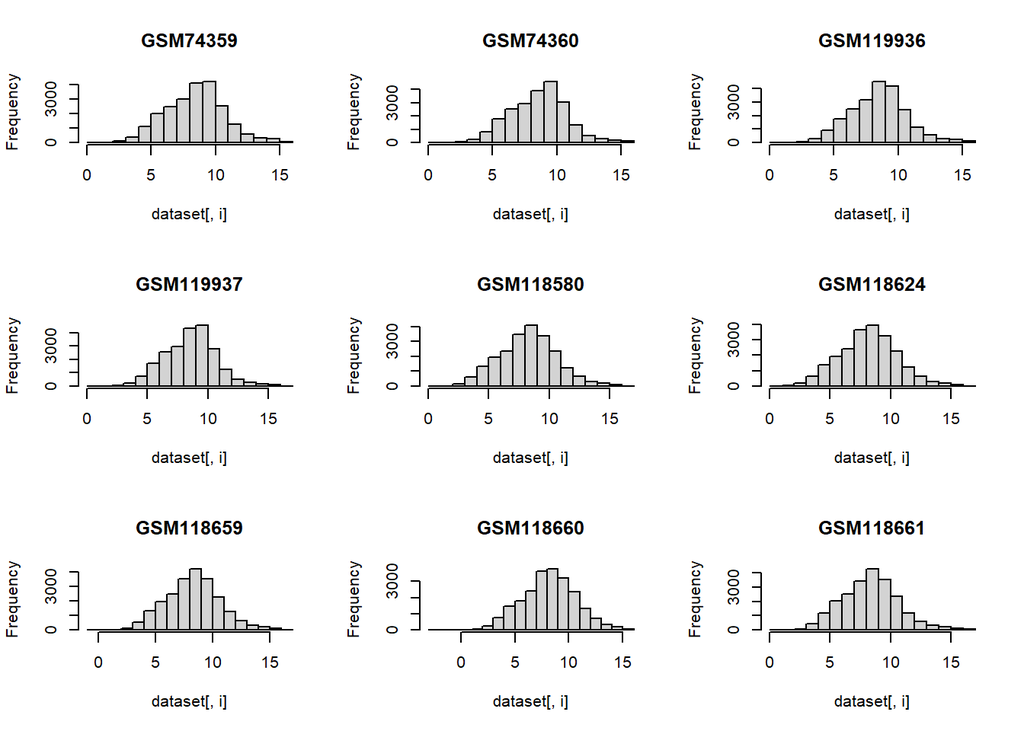

```r
colnames <- pData(eset)$sample # Extraemos una lista de los nombres de las muestras
opt <- par(mfrow=c(3,3))
for (i in 1:length(colnames))
  hist(dataset[,i], main = colnames[i])
```

```r
par(opt)
```

Observamos que todas las muestras siguen un perfil de expresión aproximadamente normal.

No se observan diferencias a simple vista entre los histogramas de las muestras normales (4 primeras) y las muestras con dermatomiositis (5 últimas).

Generamos boxplots para poder comparar mejor nuestras muestras:

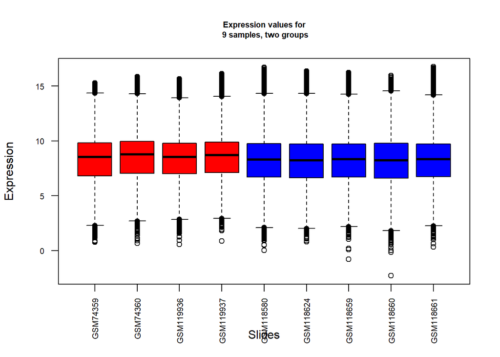

```r
groupColors <- c(rep("red", 4), rep("blue", 5))
boxplot(dataset, col=groupColors, main="Expression values for\n 9 samples, two groups",
    xlab="Slides",
    ylab="Expression", las=2, cex.axis=0.7, cex.main=0.7)
```

#### 4.2 Análisis multivariado

Generamos una matriz de correlación para ver como estan relacionados los niveles de expresión de nuestras muestras

```r
library(ggcorrplot)
data_normalized <- scale(dataset)
head(data_normalized)
```

```
##              GSM74359    GSM74360  GSM119936   GSM119937   GSM118580
## 1007_s_at  0.79108121  1.14924640  1.0583562  1.05054146  1.05746094
## 1053_at   -0.09746837 -0.35509875 -0.1734476  0.02407315 -0.09384727
## 117_at     0.05466535 -0.04473437  0.2660583  0.18154113  0.09848182
## 121_at     1.75097791  1.94730637  1.4463720  1.53291556  1.24886574
## 1255_g_at -0.19576720  0.33009267 -0.4013603 -0.46166742 -0.55962569
## 1294_at    0.57169604  0.79173598  0.1942708  0.45991837  0.60354143
##             GSM118624  GSM118659   GSM118660   GSM118661
## 1007_s_at  1.10284485  1.2204649  1.10802037  1.17134147
## 1053_at   -0.02974738 -0.3938858  0.03649543 -0.70563113
## 117_at     0.16541808  0.2657623  0.19837677  0.05534227
## 121_at     1.21365234  1.2927046  1.22532251  1.29728487
## 1255_g_at -0.49152776 -0.3544760 -0.90078227 -0.19750330
## 1294_at    0.70516296  0.5381330  1.06921778  0.51804632
```

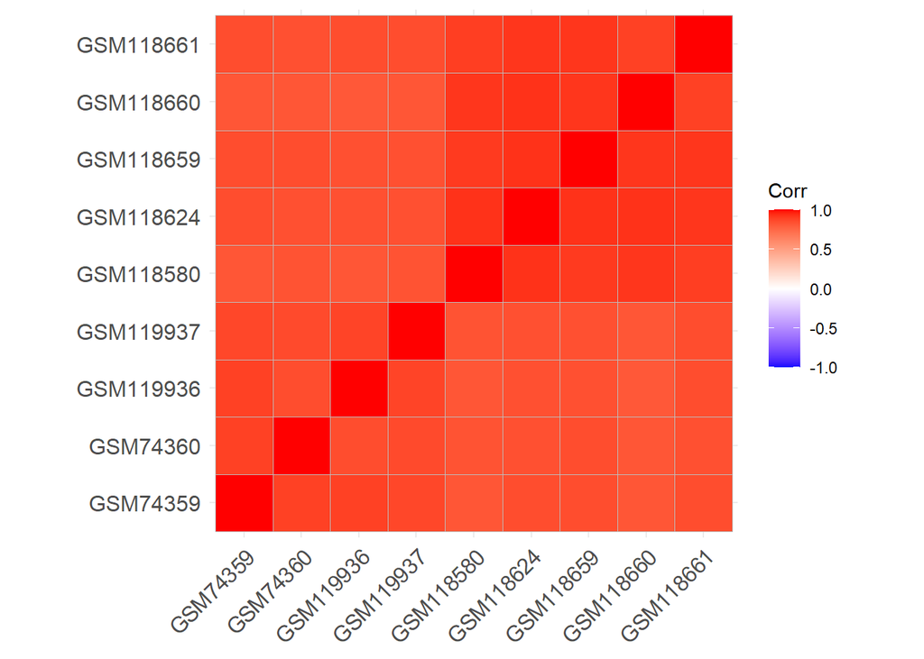

```r
corr_matrix <- cor(dataset)
ggcorrplot(corr_matrix)
```

Hacemos un análisis de PCA:

```r
pcX<-prcomp(t(dataset), scale=TRUE)
loads<- round(pcX$sdev^2/sum(pcX$sdev^2)*100,1)
```

Calculamos la variación estandar, la proporción de varianza y la varianza acumulada de cada componente:

```r
pcX<-prcomp(t(dataset), scale=TRUE)
summary(pcX)
```

```
## Importance of components:
##                            PC1     PC2     PC3     PC4      PC5      PC6
## Standard deviation     88.5153 55.1353 51.0082 48.1344 42.74004 41.70923
## Proportion of Variance  0.3516  0.1364  0.1168  0.1040  0.08198  0.07807
## Cumulative Proportion   0.3516  0.4880  0.6048  0.7088  0.79075  0.86882
##                             PC7      PC8      PC9
## Standard deviation     38.96849 37.47625 4.19e-13
## Proportion of Variance  0.06815  0.06303 0.00e+00
## Cumulative Proportion   0.93697  1.00000 1.00e+00
```

```r
prop_var <- pcX$sdev^2 / sum(pcX$sdev^2)
```

Graficamos la proporción de varianza explicada por cada componente

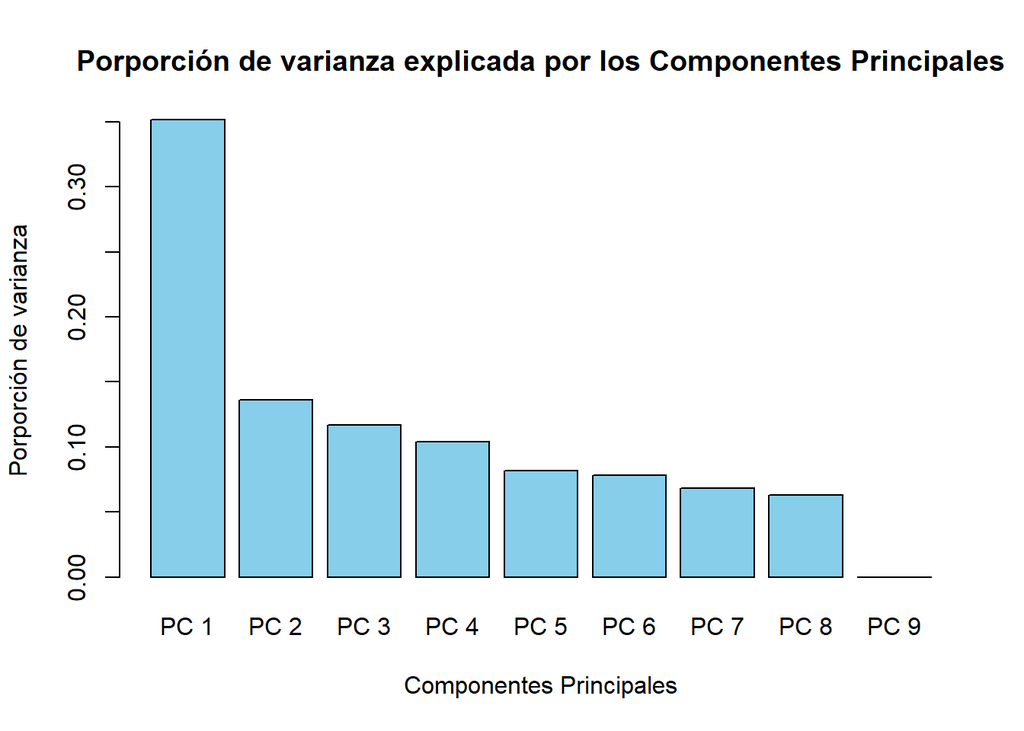

```r
# Create bar plot
barplot(prop_var,
        main = "Porporción de varianza explicada por los Componentes Principales",
        xlab = "Componentes Principales",
        ylab = "Porporción de varianza",
        names.arg = paste("PC", 1:length(prop_var)),
        col = "skyblue")
```

Graficamos la PCA:

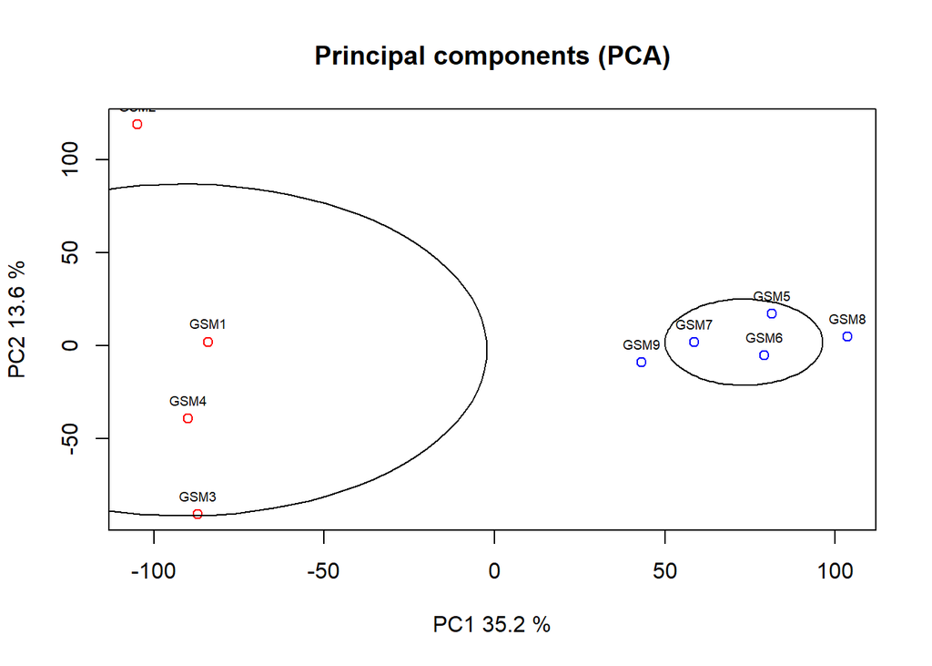

```r
xlab<-c(paste("PC1",loads[1],"%"))
ylab<-c(paste("PC2",loads[2],"%"))
plot(pcX$x[,1:2],xlab=xlab,ylab=ylab, col=groupColors,
     main ="Principal components (PCA)")
names2plot<-paste0(substr(colnames,1,3), 1:9)

text(pcX$x[,1],pcX$x[,2],names2plot, pos=3, cex=.6)

# Add circles around each group
for (i in unique(groupColors)) {
  points_in_group <- pcX$x[groupColors == i, 1:2]
  group_center <- colMeans(points_in_group)
  group_sd <- apply(points_in_group, 2, sd)
  radius <- max(group_sd)
  draw_circle <- function(center, radius, npoints=100) {
    angles <- seq(0, 2*pi, length.out=npoints)
    x <- center[1] + radius * cos(angles)
    y <- center[2] + radius * sin(angles)
    lines(x, y, col="black")
  }
  draw_circle(group_center, radius)
}
```

También observamos que la desviación estandar de los niveles de expresión entre individuos normales es mayor que entre individuos con dermatomiositis. Esto quiere decir que los niveles de expresión varian mas entre muestras normales que entre muestras con dermatomiositis.

Hacemos un análisis K-means con 3 clústers:

```r
(cl <- kmeans(dataset, 3, iter.max = 10, nstart = 1,
       algorithm = c("Hartigan-Wong", "Lloyd", "Forgy",
                     "MacQueen"), trace=FALSE))
```

```
## K-means clustering with 3 clusters of sizes 7113, 4603, 10567
##
## Cluster means:
##    GSM74359  GSM74360 GSM119936 GSM119937 GSM118580 GSM118624 GSM118659
## 1  6.066732  6.375604  6.289123  6.433334  5.757421  5.639059  5.808637
## 2 11.288587 11.241935 11.295187 11.281546 11.420353 11.462310 11.433643
## 3  8.689096  8.870311  8.681403  8.814655  8.535155  8.490815  8.548803
##   GSM118660 GSM118661
## 1  5.580988  5.909532
## 2 11.402247 11.441888
## 3  8.505254  8.536616
##
## Clustering vector:
##                   1007_s_at                     1053_at
##                           2                           3
##                      117_at                      121_at
##                           3                           2
##                   1255_g_at                     1294_at
##                           3                           3
##                     1316_at                     1320_at
##                           3                           1
##                   1405_i_at                     1431_at
##                           1                           3
##                     1438_at                     1487_at
##                           1                           2
##                   1494_f_at                   1598_g_at
##                           3                           2
##                   160020_at                     1729_at
##                           3                           3
##                     1773_at                      177_at
##                           3                           1
##                      179_at                     1861_at
##                           2                           3
##                 200000_s_at                   200001_at
##                           2                           2
##                   200002_at                 200003_s_at
##                           2                           2
##                   200004_at                   200005_at
##                           2                           2
##                   200006_at                   200007_at
```

[output cut: 22251 more lines]

```
##              AFFX-ThrX-5_at              AFFX-ThrX-M_at
##                           1                           1
##             AFFX-TrpnX-3_at             AFFX-TrpnX-5_at
##                           1                           1
##             AFFX-TrpnX-M_at
##                           1
##
## Within cluster sum of squares by cluster:
## [1] 117145.48  77909.72 103029.92
##  (between_SS / total_SS =  71.4 %)
##
## Available components:
##
## [1] "cluster"      "centers"      "totss"        "withinss"     "tot.withinss"
## [6] "betweenss"    "size"         "iter"         "ifault"
```

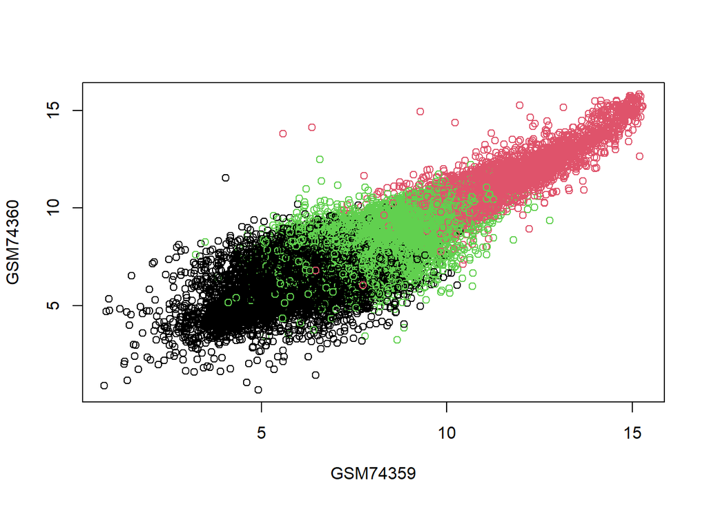

```r
plot(dataset, col = cl$cluster)
points(cl$centers, col = 1:5, pch = 8)
```

Hemos elegido 3 clústers debido a que es el número que optimiza la suma de los cuadrados (71.4 %) de las distancias entre los puntos y los centroides.

Ahora agrupamos jerárquicamente las muestras para determinar qué grupos son más cercanos y más diferentes

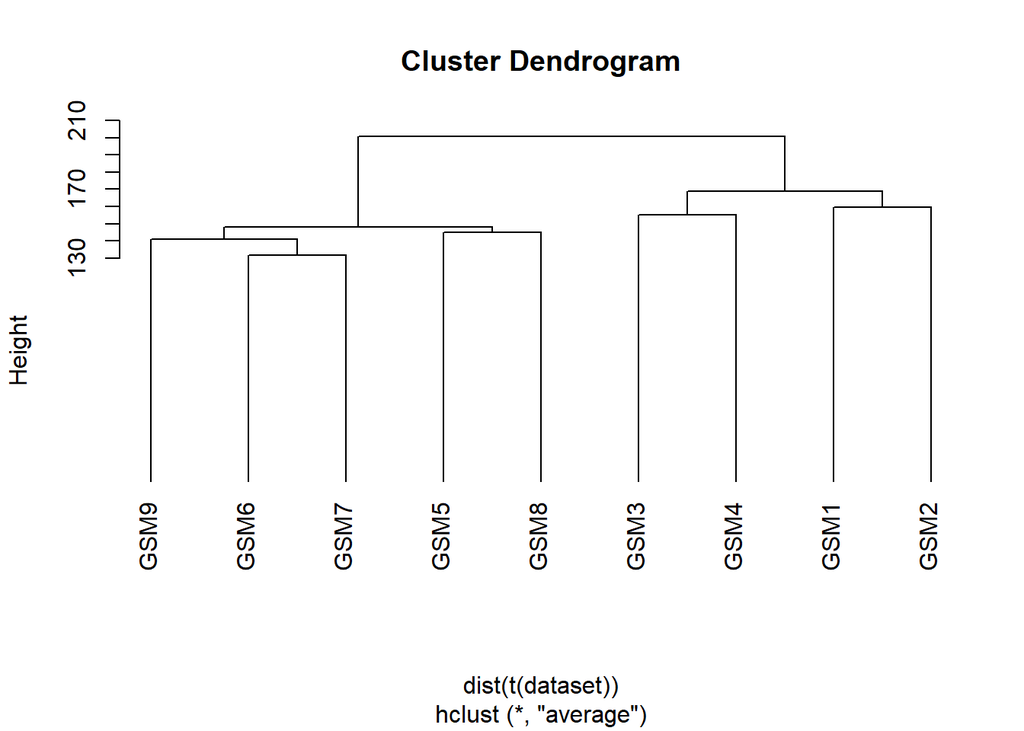

```r
colnames(dataset) <- names2plot
clust.euclid.average <- hclust(dist(t(dataset)),method="average")
plot(clust.euclid.average, hang=-1)
```

El dendograma concuerda con el PCA ya que podemos ver claramente diferenciados 2 grandes grupos, uno formado por individuos normales (a la derecha) y otro formado por los individuos que padecen dermatomiosis (a la izquierda). Dentro de estos dos grandes grupos también se generan algunas subagrupaciones en función de los valores de expresión de las muestras.